# An example using the fitness model

# An example using the fitness model

This document describe a toy example for the use of the package systemicrisk.

```r
set.seed(1238190) # arbitrary seed
library(systemicrisk)
```

Suppose we observe the following vector of total liabilities and todal assets.

```r
l <- c(714,745,246, 51,847)
a <- c(872, 412, 65, 46,1208)
```

The following sets up a model for 5 banks:

```r
mod <- Model.additivelink.exponential.fitness(n=5,alpha=-2.5,beta=0.3,gamma=1.0,
                 lambdaprior=Model.fitness.genlambdaparprior(ratescale=500))
```

```r
thin <- choosethin(l=l,a=a,model=mod,silent=TRUE)
thin
```

```
## [1] 120
```

Running the sampler to produce 1000 samples.

```r
res <- sample_HierarchicalModel(l=l,a=a,model=mod,nsamples=1e3,thin=thin,silent=TRUE)
```

Some examples of the matrics generated are below.

```r
res$L[[1]]
```

```
##            [,1]     [,2]      [,3]      [,4]      [,5]
## [1,]   0.000000 199.9657 45.479710  0.000000 468.55457
## [2,] 237.798093   0.0000  8.281059 42.077228 456.84362
## [3,]   3.746609   0.0000  0.000000  0.000000 242.25339
## [4,]  10.651586   0.0000  0.000000  0.000000  40.34841
## [5,] 619.803712 212.0343 11.239231  3.922772   0.00000
```

```r
res$L[[2]]
```

```
##          [,1]      [,2]     [,3] [,4]     [,5]
## [1,]   0.0000  21.65717  0.00000    0 692.3428
## [2,] 361.4501   0.00000 18.17048    0 365.3794
## [3,]   0.0000  95.72222  0.00000    0 150.2778
## [4,]   0.0000  51.00000  0.00000    0   0.0000
## [5,] 510.5499 243.62062 46.82952   46   0.0000
```

The sampler produces samples from the conditional distribution of matrix and parameter values given the observed data. To see the posterior distribution of the liabilities of Bank 1 towards Bank 2:

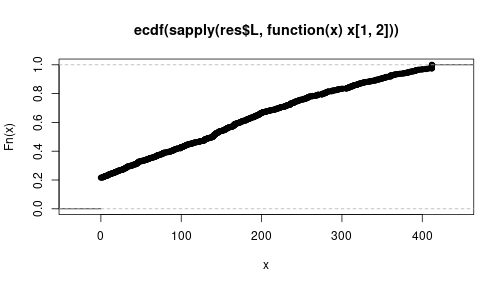

```r
plot(ecdf(sapply(res$L,function(x)x[1,2])))
```

## Diagnostic of the R-output

All the caveats of MCMC algorithms apply. In particular the samples are dependent.

Some automatic diagnostic can be generated via the function diagnose.

```r
diagnose(res)
```

```
## Analysis does not consider 5 entries of matrix
## that are deterministic (diagonal elements, row/column sum=0 or forced result).
```

```
## All remaining elements of the liabilities matrix have moved during sample run.
```

```
## Summary of ESS in matrix: Min.= 839.4 1st Qu.= 976.9 Median=1000.0 Mean= 975.4 3rd Qu.=1000.0 Max.=1222.3
```

```
## Summary of ESS in theta: Min.= 677.8 1st Qu.= 811.8 Median=1000.0 Mean= 900.2 3rd Qu.=1000.0 Max.=1000.0
```

Trace plots of individual liabilities also shoud show rapid mixing - as seems to be the case for the liabilities of Bank 1 towards Bank 2.

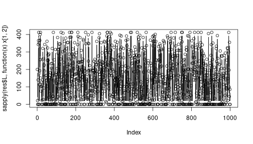

```r
plot(sapply(res$L,function(x)x[1,2]),type="b")
```

Trace plot of the fitness of bank 1.

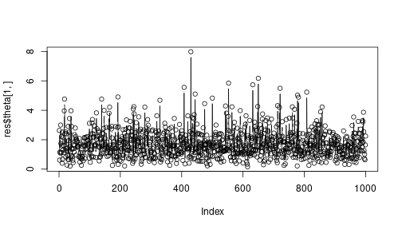

```r
plot(res$theta[1,],type="b")
```

Also, the autocorrelation function should decline quickly. Again, considering the liabilities between bank 1 and bank 2:

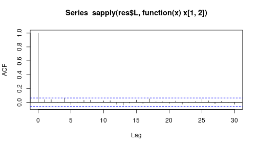

```r
acf(sapply(res$L,function(x)x[1,2]))
```

In this case it decays quickly below the white-noise threshold (the horizontal dashed lines).